# Cyclistic Case Study

Kent Tse

# Cyclistic 12 Month Analysis

This analysis is based on the Cyclistic case study for the Google Data Analytics Certificate.

**Task:** Analyze past 12 months of historical bikeshare trip data to determine how annual members and casual riders use Cyclistic bikes differently.

**Dataset:** Monthly trip data from September 2020 to August 2021 was used in this case study.The data is anonymized for data-privacy, omitting any personally identifiable information. The data contains trip start day and time, end day and time, start station, end station, and rider type. The data is been processed to remove maintenance trips and trips below 60 seconds in length are noted as potentially false starts.

The data used in this case study is public and provided by Motivate International Inc. under the following license: https://www.divvybikes.com/data-license-agreement

#### Required packages

The following packages will be used:

- tidyverse for data import and wrangling
- lubridate for date functions
- ggplot2 for visualization
- scales for axis values
- leaflet for interactive map

```r
library(tidyverse)
library(lubridate)
library(ggplot2)
library(scales)
library(leaflet)
```

# Part 1: Data Cleaning and Processing

### Import data

```r
getwd() # to display working directory
setwd("/Users/Kent/Documents/Side Projects/R/CYCLISTIC/raw data/") # set to appropriate working directory
sep_2020 <- read_csv("202009-divvy-tripdata.csv")
oct_2020 <- read_csv("202010-divvy-tripdata.csv")
nov_2020 <- read_csv("202011-divvy-tripdata.csv")
dec_2020 <- read_csv("202012-divvy-tripdata.csv")
jan_2021 <- read_csv("202101-divvy-tripdata.csv")
feb_2021 <- read_csv("202102-divvy-tripdata.csv")
mar_2021 <- read_csv("202103-divvy-tripdata.csv")
apr_2021 <- read_csv("202104-divvy-tripdata.csv")
may_2021 <- read_csv("202105-divvy-tripdata.csv")
jun_2021 <- read_csv("202106-divvy-tripdata.csv")
jul_2021 <- read_csv("202107-divvy-tripdata.csv")
aug_2021 <- read_csv("202108-divvy-tripdata.csv")
```

### Wrangle data and combine into a single file

Make sure that column names match before joining into one file

```r
colnames(sep_2020)
colnames(oct_2020)
colnames(nov_2020)
colnames(dec_2020)
colnames(jan_2021)
colnames(feb_2021)
colnames(mar_2021)
colnames(apr_2021)
colnames(may_2021)
colnames(jun_2021)
colnames(jul_2021)
colnames(aug_2021)
```

Check the structure of the data to make sure it’s consistent

```r
str(sep_2020)
str(oct_2020)
str(nov_2020)
str(dec_2020)
str(jan_2021)
str(feb_2021)
str(mar_2021)
str(apr_2021)
str(may_2021)
str(jun_2021)
str(jul_2021)
str(aug_2021)
```

The data type for “start_station_id” and “end_station_id” in “sep_2020”, “oct_2020”, and nov_2020” are doubles (numeric) where as the rest of the sheets are characters.

Convert “start_station_id” and “end_station_id” to character as well to stack the sheets correctly.

```r
sep_2020 <- mutate(sep_2020,start_station_id=as.character(start_station_id),
                   end_station_id=as.character(end_station_id))
oct_2020 <- mutate(oct_2020,start_station_id=as.character(start_station_id),
                   end_station_id=as.character(end_station_id))
nov_2020 <- mutate(nov_2020,start_station_id=as.character(start_station_id),
                   end_station_id=as.character(end_station_id))
```

```r
all_trips <- bind_rows(sep_2020,oct_2020,nov_2020,dec_2020,jan_2021,feb_2021,mar_2021,apr_2021,may_2021,jun_2021,jul_2021,aug_2021)
```

### Clean data for analysis

First, get an overview of the data frame “all_trips”.

To prepare the data for analysis:

- Validate that the “member_casual” column has only two names: casual and member
- Add columns for date, month, day, and year of each ride to aggregate
- Add a calculated field for trip duration called “ride_length”
- Check that “ride_length” has no negative values
- Check for any missing values in the data

#### Overview of “all_trips”

```r
colnames(all_trips)
```

```
##  [1] "ride_id"            "rideable_type"      "started_at"
##  [4] "ended_at"           "start_station_name" "start_station_id"
##  [7] "end_station_name"   "end_station_id"     "start_lat"
## [10] "start_lng"          "end_lat"            "end_lng"
## [13] "member_casual"
```

```r
nrow(all_trips)
```

```
## [1] 4913072
```

```r
dim(all_trips)
```

```
## [1] 4913072      13
```

```r
head(all_trips)
```

```
## # A tibble: 6 × 13
##   ride_id rideable_type started_at          ended_at            start_station_n…
##   <chr>   <chr>         <dttm>              <dttm>              <chr>
## 1 2B22BD… electric_bike 2020-09-17 14:27:11 2020-09-17 14:44:24 Michigan Ave & …
## 2 A7FB70… electric_bike 2020-09-17 15:07:31 2020-09-17 15:07:45 W Oakdale Ave &…
## 3 86057F… electric_bike 2020-09-17 15:09:04 2020-09-17 15:09:35 W Oakdale Ave &…
## 4 57F6DC… electric_bike 2020-09-17 18:10:46 2020-09-17 18:35:49 Ashland Ave & B…
## 5 B9C471… electric_bike 2020-09-17 15:16:13 2020-09-17 15:52:55 Fairbanks Ct & …
## 6 378BBC… electric_bike 2020-09-17 18:37:04 2020-09-17 19:23:28 Clark St & Armi…
## # … with 8 more variables: start_station_id <chr>, end_station_name <chr>,
## #   end_station_id <chr>, start_lat <dbl>, start_lng <dbl>, end_lat <dbl>,
## #   end_lng <dbl>, member_casual <chr>
```

```r
str(all_trips)
```

```
## spec_tbl_df [4,913,072 × 13] (S3: spec_tbl_df/tbl_df/tbl/data.frame)
##  $ ride_id           : chr [1:4913072] "2B22BD5F95FB2629" "A7FB70B4AFC6CAF2" "86057FA01BAC778E" "57F6DC9A153DB98C" ...
##  $ rideable_type     : chr [1:4913072] "electric_bike" "electric_bike" "electric_bike" "electric_bike" ...
##  $ started_at        : POSIXct[1:4913072], format: "2020-09-17 14:27:11" "2020-09-17 15:07:31" ...
##  $ ended_at          : POSIXct[1:4913072], format: "2020-09-17 14:44:24" "2020-09-17 15:07:45" ...
##  $ start_station_name: chr [1:4913072] "Michigan Ave & Lake St" "W Oakdale Ave & N Broadway" "W Oakdale Ave & N Broadway" "Ashland Ave & Belle Plaine Ave" ...
##  $ start_station_id  : chr [1:4913072] "52" NA NA "246" ...
##  $ end_station_name  : chr [1:4913072] "Green St & Randolph St" "W Oakdale Ave & N Broadway" "W Oakdale Ave & N Broadway" "Montrose Harbor" ...
##  $ end_station_id    : chr [1:4913072] "112" NA NA "249" ...
##  $ start_lat         : num [1:4913072] 41.9 41.9 41.9 42 41.9 ...
##  $ start_lng         : num [1:4913072] -87.6 -87.6 -87.6 -87.7 -87.6 ...
##  $ end_lat           : num [1:4913072] 41.9 41.9 41.9 42 41.9 ...
##  $ end_lng           : num [1:4913072] -87.6 -87.6 -87.6 -87.6 -87.6 ...
##  $ member_casual     : chr [1:4913072] "casual" "casual" "casual" "casual" ...
##  - attr(*, "spec")=
##   .. cols(
##   ..   ride_id = col_character(),
##   ..   rideable_type = col_character(),
##   ..   started_at = col_datetime(format = ""),
##   ..   ended_at = col_datetime(format = ""),
##   ..   start_station_name = col_character(),
##   ..   start_station_id = col_double(),
##   ..   end_station_name = col_character(),
##   ..   end_station_id = col_double(),
##   ..   start_lat = col_double(),
##   ..   start_lng = col_double(),
##   ..   end_lat = col_double(),
##   ..   end_lng = col_double(),
##   ..   member_casual = col_character()
##   .. )
##  - attr(*, "problems")=<externalptr>
```

```r
summary(all_trips)
```

```
##    ride_id          rideable_type        started_at
##  Length:4913072     Length:4913072     Min.   :2020-09-01 00:00:07
##  Class :character   Class :character   1st Qu.:2020-12-09 18:57:27
##  Mode  :character   Mode  :character   Median :2021-05-26 16:51:05
##                                        Mean   :2021-04-11 06:27:48
##                                        3rd Qu.:2021-07-17 03:36:04
##                                        Max.   :2021-08-31 23:59:35
##
##     ended_at                   start_station_name start_station_id
##  Min.   :2020-09-01 00:04:43   Length:4913072     Length:4913072
##  1st Qu.:2020-12-09 18:29:54   Class :character   Class :character
##  Median :2021-05-26 17:12:45   Mode  :character   Mode  :character
##  Mean   :2021-04-11 06:48:57
##  3rd Qu.:2021-07-17 04:16:25
##  Max.   :2021-09-01 17:37:35
##
##  end_station_name   end_station_id       start_lat       start_lng
##  Length:4913072     Length:4913072     Min.   :41.64   Min.   :-87.84
##  Class :character   Class :character   1st Qu.:41.88   1st Qu.:-87.66
##  Mode  :character   Mode  :character   Median :41.90   Median :-87.64
##                                        Mean   :41.90   Mean   :-87.65
##                                        3rd Qu.:41.93   3rd Qu.:-87.63
##                                        Max.   :42.08   Max.   :-87.52
##
##     end_lat         end_lng       member_casual
##  Min.   :41.51   Min.   :-88.07   Length:4913072
##  1st Qu.:41.88   1st Qu.:-87.66   Class :character
##  Median :41.90   Median :-87.64   Mode  :character
##  Mean   :41.90   Mean   :-87.64
##  3rd Qu.:41.93   3rd Qu.:-87.63
##  Max.   :42.15   Max.   :-87.44
##  NA's   :5015    NA's   :5015
```

#### Validate “member_casual” column

```r
table(all_trips$member_casual) #Check values in "member_casual" column
```

```
##
##  casual  member
## 2225089 2687983
```

```r
#Use the following if changes need to be made:
#all_trips <- all_trips %>%
#  mutate(member_casual=recode(member_casual,
#                              "EDIT"="member",
#                              "EDIT"="casual"))
#table(all_trips$member_casual)
```

#### Create new columns for date, month, day, year, and day of week

```r
all_trips$date <- as.Date(all_trips$started_at)
all_trips$month <- format(as.Date(all_trips$date),"%m")
all_trips$day <- format(as.Date(all_trips$date),"%d")
all_trips$year <- format(as.Date(all_trips$date),"%Y")
all_trips$day_of_week <- format(as.Date(all_trips$date),"%A")
```

#### Add “ride_length” column to calculate trip duration in seconds

```r
all_trips$ride_length <- difftime(all_trips$ended_at,all_trips$started_at)
str(all_trips) #Verify that data types are correct

## Use following chunk if "ride_length" is not numeric
#typeof(all_trips$ride_length)
#all_trips$ride_length <- as.numeric(as.character(all_trips$ride_length))
```

#### Remove rows with missing and negative values in “ride_length”

```r
all_trips_v2 <- all_trips[!(is.na(all_trips$ride_length)|all_trips$ride_length<0),]
```

#### Remove test trips and trips under 60 sec

There appears to be many entries with ride duration of 0 sec and less than 1 minute. Some of these entries were made from fasle starts or may be from re-racking of bikes according to the notes about the data.

```r
all_trips_v3 <- all_trips_v2 %>%
  filter(!(ride_length < 60))
```

#### Check for blank values

```r
colSums(is.na(all_trips_v3))
```

```
##            ride_id      rideable_type         started_at           ended_at
##                  0                  0                  0                  0
## start_station_name   start_station_id   end_station_name     end_station_id
##             434115             434604             472371             472718
##          start_lat          start_lng            end_lat            end_lng
##                  0                  0               4942               4942
##      member_casual               date              month                day
##                  0                  0                  0                  0
##               year        day_of_week        ride_length
##                  0                  0                  0
```

It appears that there are many incomplete entries for start_station_name, start_station_id, end_station_name, end_station_id, end_lat, and end_lng.

Let’s filter the data by removing these incomplete rows

```r
all_trips_v3 <- all_trips_v3 %>%
  filter(!(is.na(start_station_name))) %>%
  filter(!(is.na(end_station_name))) %>%
  filter(!(is.na(start_station_id))) %>%
  filter(!(is.na(end_station_id)))

colSums(is.na(all_trips_v3))
```

```
##            ride_id      rideable_type         started_at           ended_at
##                  0                  0                  0                  0
## start_station_name   start_station_id   end_station_name     end_station_id
##                  0                  0                  0                  0
##          start_lat          start_lng            end_lat            end_lng
##                  0                  0                  0                  0
##      member_casual               date              month                day
##                  0                  0                  0                  0
##               year        day_of_week        ride_length
##                  0                  0                  0
```

# Part 2: Analysis

### Analyze the data:

- Calculate mean, median, max, and min for “ride_length”
- Aggregate data to compare members and casual riders
- Calculate average “ride_length” for members and casual riders by day of week
- Analyze the times that rides are taken throughout the days of the week
- Analyze number of rides and average ride time for members vs casual riders by day of week
- Analyze number of rides by month (seasonal differences)

### Summary statistics for ride length

```r
summary(all_trips_v3$ride_length)
```

```
##   Length    Class     Mode
##  4172890 difftime  numeric
```

#### Aggregate data to compare members and casual riders

```r
aggregate(all_trips_v3$ride_length ~ all_trips_v3$member_casual, FUN=mean)
```

```
##   all_trips_v3$member_casual all_trips_v3$ride_length
## 1                     casual               2118.5453
## 2                     member                850.5781
```

```r
aggregate(all_trips_v3$ride_length ~ all_trips_v3$member_casual, FUN=median)
```

```
##   all_trips_v3$member_casual all_trips_v3$ride_length
## 1                     casual                    1075
## 2                     member                     626
```

```r
aggregate(all_trips_v3$ride_length ~ all_trips_v3$member_casual, FUN=max)
```

```
##   all_trips_v3$member_casual all_trips_v3$ride_length
## 1                     casual                 3356649
## 2                     member                 1870176
```

```r
aggregate(all_trips_v3$ride_length ~ all_trips_v3$member_casual, FUN=min)
```

```
##   all_trips_v3$member_casual all_trips_v3$ride_length
## 1                     casual                      60
## 2                     member                      60
```

### Average ride length by day of week

```r
# First set order the day of week
all_trips_v3$day_of_week <- ordered(all_trips_v3$day_of_week, levels=c("Sunday","Monday","Tuesday","Wednesday","Thursday","Friday","Saturday"))
#Now calculate average "ride_length" for members vs casual riders by day of week
aggregate(all_trips_v3$ride_length ~ all_trips_v3$member_casual+all_trips_v3$day_of_week,FUN=mean)
```

```
##    all_trips_v3$member_casual all_trips_v3$day_of_week all_trips_v3$ride_length
## 1                      casual                   Sunday               2437.1121
## 2                      member                   Sunday                978.9865
## 3                      casual                   Monday               2090.3095
## 4                      member                   Monday                812.8977
## 5                      casual                  Tuesday               1879.2016
## 6                      member                  Tuesday                801.1597
## 7                      casual                Wednesday               1891.9136
## 8                      member                Wednesday                804.3294
## 9                      casual                 Thursday               1821.9728
## 10                     member                 Thursday                795.7621
## 11                     casual                   Friday               2029.3298
## 12                     member                   Friday                832.9988
## 13                     casual                 Saturday               2274.3740
## 14                     member                 Saturday                948.8004
```

### Total number of rides and average ride length by day of week

```r
all_trips_v3 %>%
  mutate(weekday=wday(started_at,label = TRUE)) %>% #Create weekday column
  group_by(member_casual,weekday) %>% #Group by user type and weekday
  summarise(number_of_rides=n(), #Number of rides and average duration
            average_duration=mean(ride_length)) %>%
  arrange(member_casual,weekday) #Sort by user type and weekday
```

```
## # A tibble: 14 × 4
## # Groups:   member_casual [2]
##    member_casual weekday number_of_rides average_duration
##    <chr>         <ord>             <int> <drtn>
##  1 casual        Sun              361920 2437.1121 secs
##  2 casual        Mon              207806 2090.3095 secs
##  3 casual        Tue              197825 1879.2016 secs
##  4 casual        Wed              198599 1891.9136 secs
##  5 casual        Thu              202948 1821.9728 secs
##  6 casual        Fri              267045 2029.3298 secs
##  7 casual        Sat              429589 2274.3740 secs
##  8 member        Sun              288109  978.9865 secs
##  9 member        Mon              314096  812.8977 secs
## 10 member        Tue              345499  801.1597 secs
## 11 member        Wed              352613  804.3294 secs
## 12 member        Thu              336492  795.7621 secs
## 13 member        Fri              338307  832.9988 secs
## 14 member        Sat              332042  948.8004 secs
```

#### Visualize number of member and casual rides throughout the week

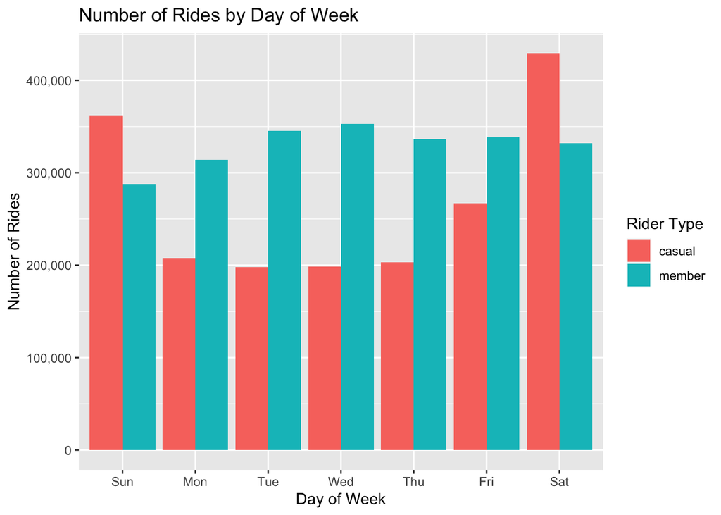

```r
all_trips_v3 %>%
  mutate(weekday=wday(started_at,label = TRUE)) %>%
  group_by(member_casual,weekday) %>%
  summarise(number_of_rides=n(),
            average_duration=mean(ride_length)) %>%
  arrange(member_casual,weekday) %>%
  ggplot(aes(x=weekday,y=number_of_rides,fill=member_casual))+
    geom_col(position = "dodge")+
    labs(title = "Number of Rides by Day of Week",
         fill="Rider Type",
         x = "Day of Week",
         y = "Number of Rides")+
    scale_y_continuous(labels=comma)
```

#### Visualize average ride duration of members and casual riders

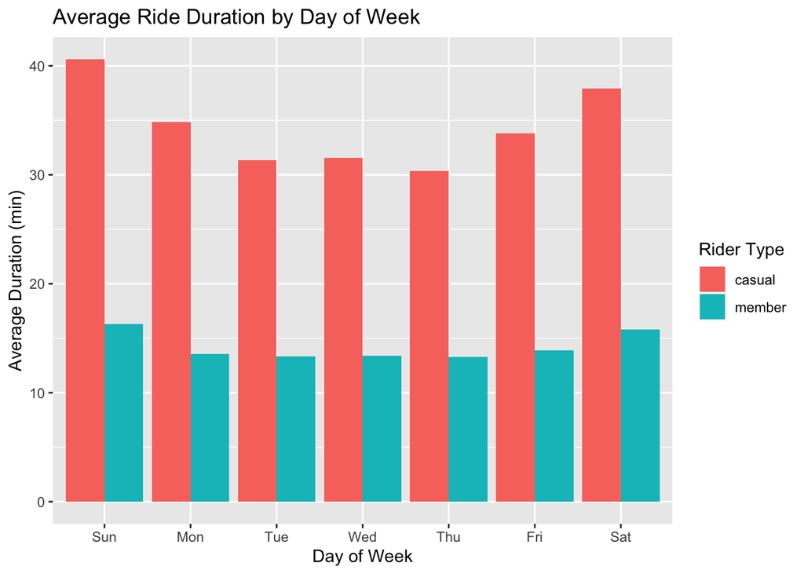

```r
all_trips_v3 %>%
  mutate(weekday=wday(started_at,label = TRUE),ride_length=(ride_length/60)) %>%
  group_by(member_casual,weekday) %>%
  summarise(number_of_rides=n(),
            average_duration=mean(ride_length)) %>%
  arrange(member_casual,weekday) %>%
  ggplot(aes(x=weekday,y=average_duration,fill=member_casual))+
  geom_col(position = "dodge")+
  labs(title = "Average Ride Duration by Day of Week",
       fill="Rider Type",
       x = "Day of Week",
       y = "Average Duration (min)")
```

### Number of rides by hour on weekdays

```r
all_trips_v3 %>%
  filter(day_of_week != "Saturday" & day_of_week != "Sunday") %>%
  mutate(start_hour=hour(started_at)) %>%
  group_by(member_casual,start_hour) %>%
  summarise(number_of_rides=n()) %>%
  arrange(member_casual,start_hour)
```

```
## # A tibble: 48 × 3
## # Groups:   member_casual [2]
##    member_casual start_hour number_of_rides
##    <chr>              <int>           <int>
##  1 casual                 0           13786
##  2 casual                 1            8032
##  3 casual                 2            4439
##  4 casual                 3            2585
##  5 casual                 4            2550
##  6 casual                 5            4896
##  7 casual                 6           13286
##  8 casual                 7           24080
##  9 casual                 8           30097
## 10 casual                 9           29143
## # … with 38 more rows
```

#### Visualize number of rides by hour on weekdays

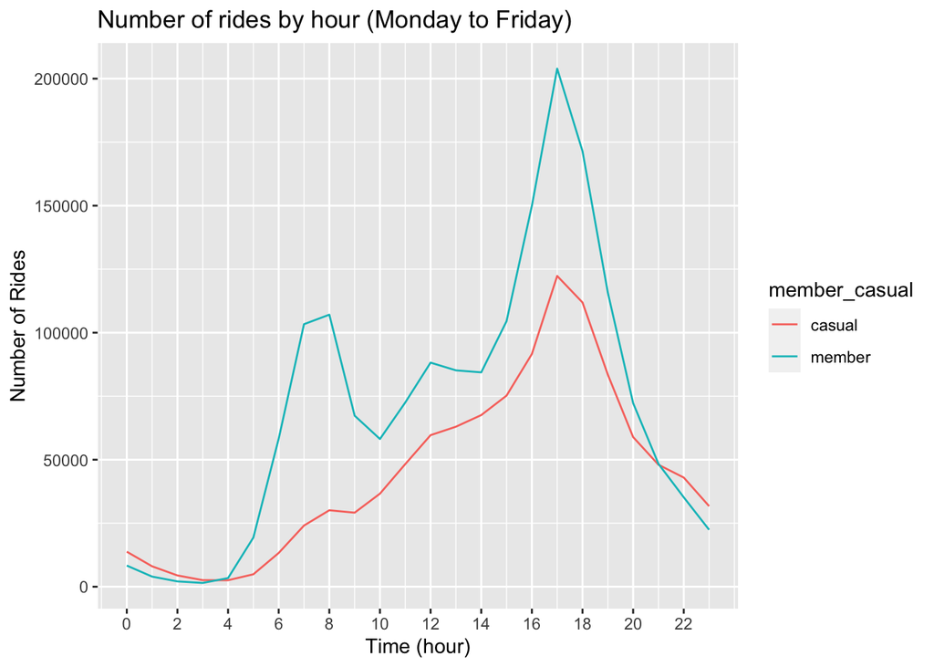

```r
all_trips_v3 %>%
  filter(day_of_week != "Saturday" & day_of_week != "Sunday") %>%
  mutate(start_hour=hour(started_at)) %>%
  group_by(member_casual,start_hour) %>%
  summarise(number_of_rides=n()) %>%
  arrange(member_casual,start_hour) %>%
  ggplot(aes(x=start_hour,y=number_of_rides,color=member_casual))+
  geom_line()+
  labs(title = "Number of rides by hour (Monday to Friday)",
       x = "Time (hour)",
       y = "Number of Rides")+
  scale_x_continuous(breaks = seq(0,23,2))
```

### Number of rides by hour on weekends

```r
all_trips_v3 %>%
  filter(day_of_week == "Saturday" | day_of_week == "Sunday") %>%
  mutate(start_hour=hour(started_at)) %>%
  group_by(member_casual,start_hour) %>%
  summarise(number_of_rides=n()) %>%
  arrange(member_casual,start_hour)
```

```
## # A tibble: 48 × 3
## # Groups:   member_casual [2]
##    member_casual start_hour number_of_rides
##    <chr>              <int>           <int>
##  1 casual                 0           22722
##  2 casual                 1           17924
##  3 casual                 2           11712
##  4 casual                 3            5853
##  5 casual                 4            3007
##  6 casual                 5            2363
##  7 casual                 6            3353
##  8 casual                 7            6148
##  9 casual                 8           12081
## 10 casual                 9           23446
## # … with 38 more rows
```

#### Visualize number of rides by hour on weekends

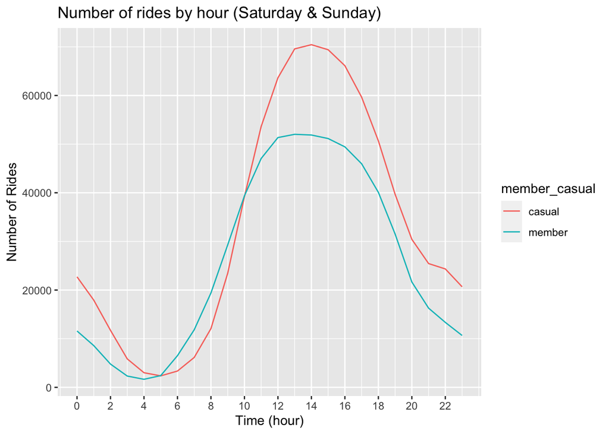

```r
all_trips_v3 %>%
  filter(day_of_week == "Saturday" | day_of_week == "Sunday") %>%
  mutate(start_hour=hour(started_at)) %>%
  group_by(member_casual,start_hour) %>%
  summarise(number_of_rides=n()) %>%
  arrange(member_casual,start_hour) %>%
  ggplot(aes(x=start_hour,y=number_of_rides,color=member_casual))+
  geom_line()+
  labs(title = "Number of rides by hour (Saturday & Sunday)",
       x = "Time (hour)",
       y = "Number of Rides")+
  scale_x_continuous(breaks = seq(0,23,2))
```

### Number of rides by month

```r
all_trips_v3 %>%
  mutate(month=factor(month.abb[as.numeric(month)],levels=month.abb)) %>%
  group_by(member_casual,month) %>%
  summarise(number_of_rides=n()) %>%
  arrange(member_casual,month)
```

```
## # A tibble: 24 × 3
## # Groups:   member_casual [2]
##    member_casual month number_of_rides
##    <chr>         <fct>           <int>
##  1 casual        Jan             14583
##  2 casual        Feb              8508
##  3 casual        Mar             75059
##  4 casual        Apr            119362
##  5 casual        May            214652
##  6 casual        Jun            300769
##  7 casual        Jul            365513
##  8 casual        Aug            338138
##  9 casual        Sep            212122
## 10 casual        Oct            120597
## # … with 14 more rows
```

#### Visualize number of rides by month

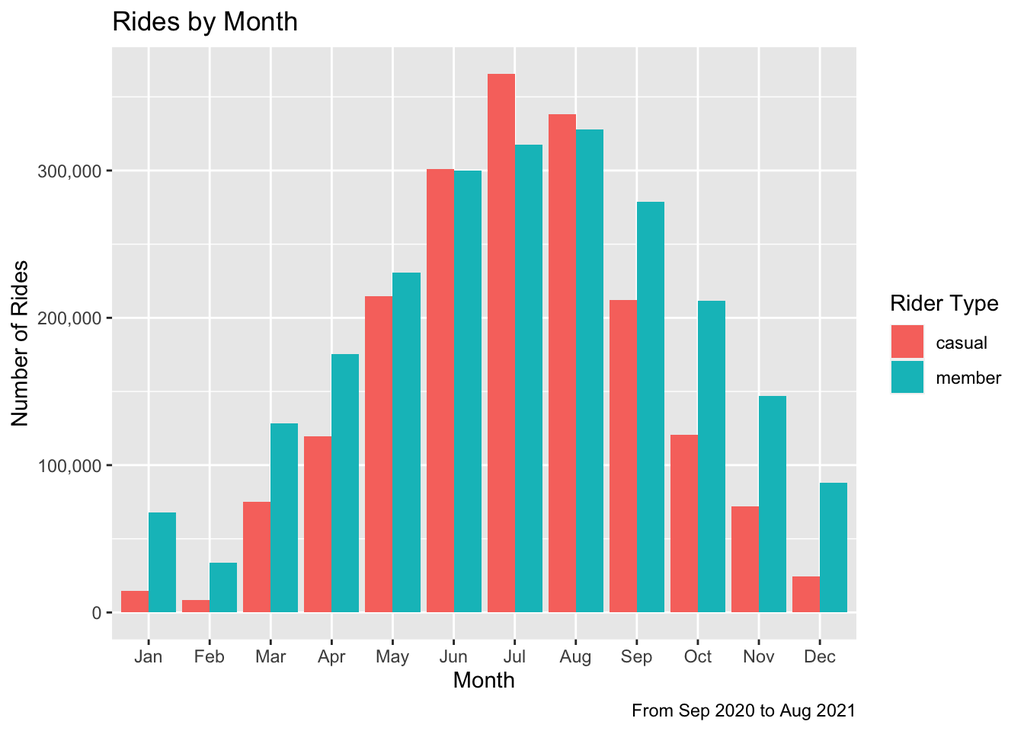

```r
all_trips_v3 %>%
  mutate(month=factor(month.abb[as.numeric(month)],levels=month.abb)) %>%
  group_by(member_casual,month) %>%
  summarise(number_of_rides=n()) %>%
  arrange(member_casual,month) %>%
  ggplot(aes(x=month,y=number_of_rides,fill=member_casual))+
  geom_col(position="dodge")+
  labs(title = "Rides by Month",caption = "From Sep 2020 to Aug 2021",fill="Rider Type")+
  ylab("Number of Rides")+
  xlab("Month")+
  scale_y_continuous(labels=comma)
```

### Mapping the coordinates

```r
start_map_data <- all_trips_v3 %>%
  select(member_casual, start_station_name, start_lat, start_lng) %>%
  group_by(member_casual, start_station_name) %>%
  mutate(num_trips = n()) %>%
  distinct(start_station_name,.keep_all = TRUE)

end_map_data <- all_trips_v3 %>%
  select(member_casual, end_station_name, end_lat, end_lng) %>%
  group_by(member_casual, end_station_name) %>%
  mutate(num_trips = n()) %>%
  distinct(end_station_name,.keep_all = TRUE)
```

#### Casual rides map

```r
casual_start <- start_map_data %>%
  filter(member_casual == "casual")

casual_end <- end_map_data %>%
  filter(member_casual =="casual")

# create color palette for markers and legend
cpal1 <- colorBin(
  palette = "viridis",
  domain = casual_start$num_trips,
  bins = 5
  )

cpal2 <- colorBin(
  palette = "viridis",
  domain = casual_end$num_trips,
  bins = 5
  )

# create map to show number of casual trips per station
casual_map <- leaflet() %>%
  setView(lng = -87.62311, lat = 41.881832, zoom = 12) %>%  # set coordinates for Chicago
  addTiles() %>% # add default OSM tiles
  addCircleMarkers(
    data = casual_start,
    ~start_lng,
    ~start_lat,
    group = "Trip Start",
    stroke = FALSE,
    fillColor = ~cpal1(num_trips),
    fillOpacity = 0.7,
    radius = log(casual_start$num_trips), # marker size will vary based on number of trips
    popup = ~paste("Station: ", casual_start$start_station_name,"<br/>",
                   "Number of trips: ", casual_start$num_trips)
  ) %>%

  addLegend(
    data = casual_start,
    pal = cpal1,
    values = ~num_trips,
    opacity = 0.7,
    title = "Number of trips (Start)",
    position = "bottomright",
    group = "Trip Start"
  ) %>%

   addCircleMarkers(
    data = casual_end,
    ~end_lng,
    ~end_lat,
    group = "Trip End",
    stroke = FALSE,
    fillColor = ~cpal2(num_trips),
    fillOpacity = 0.7,
    radius = log(casual_end$num_trips),
    popup = ~paste("Station: ", casual_end$end_station_name,"<br/>",
                   "Number of trips: ", casual_end$num_trips)
  ) %>%

  addLegend(
    data = casual_end,
    pal = cpal2,
    values = ~num_trips,
    opacity = 0.7,
    title = "Number of trips (End)",
    position = "bottomright",
    group = "Trip End"
  ) %>%

  # Layer controls to select view of start stations and end stations
  addLayersControl(
    overlayGroups = c("Trip Start","Trip End"),
    options = layersControlOptions(collapsed = FALSE)
  )

casual_map
```

[interactive chart not shown]

#### Member rides map

```r
member_start <- start_map_data %>%
  filter(member_casual == "member")

member_end <- end_map_data %>%
  filter(member_casual =="member")

# create color palette for markers and legend
mpal1 <- colorBin(
  palette = "viridis",
  domain = member_start$num_trips,
  bins = 5
  )

mpal2 <- colorBin(
  palette = "viridis",
  domain = member_end$num_trips,
  bins = 5
  )

# create map to show number of member trips per station
member_map <- leaflet() %>%
  setView(lng = -87.62311, lat = 41.881832, zoom = 12) %>% # set coordinates for Chicago
  addTiles() %>%  # add default OSM tiles
  addCircleMarkers( # create circle markers to represent each start station
    data = member_start,
    ~start_lng,
    ~start_lat,
    group = "Trip Start",
    stroke = FALSE,
    fillColor = ~mpal1(num_trips),
    fillOpacity = 0.7,
    radius = log(member_start$num_trips), # marker size will vary based on number of trips
    popup = ~paste("Station: ", member_start$start_station_name,"<br/>",
                   "Number of trips: ", member_start$num_trips)
  ) %>%

  addLegend(
    data = member_start,
    pal = mpal1,
    values = ~num_trips,
    opacity = 0.7,
    title = "Number of trips (Start)",
    position = "bottomright",
    group = "Trip Start"
  ) %>%

   addCircleMarkers(
    data = member_end,
    ~end_lng,
    ~end_lat,
    group = "Trip End",
    stroke = FALSE,
    fillColor = ~mpal2(num_trips),
    fillOpacity = 0.7,
    radius = log(member_end$num_trips),
    popup = ~paste("Station: ", member_end$end_station_name,"<br/>",
                   "Number of trips: ", member_end$num_trips)
  ) %>%

  addLegend(
    data = member_end,
    pal = mpal2,
    values = ~num_trips,
    opacity = 0.7,
    title = "Number of trips (End)",
    position = "bottomright",
    group = "Trip End"
  ) %>%

  # add layer control to select view of start stations and end stations
  addLayersControl(
    overlayGroups = c("Trip Start","Trip End"),
    options = layersControlOptions(collapsed = FALSE)
  )

member_map
```

[interactive chart not shown]

```r
top_10_stations <- start_map_data %>%
  arrange(desc(num_trips)) %>%
  group_by(member_casual) %>%
  slice(1:10)
```